# Alzheimer Diagnoses Predictions

caitl-k

## Data Understanding

### Loading

```r
alz.df <- read.csv("alzheimers.csv")
```

### Quality Evaluation

```r
str(alz.df)
```

```
## 'data.frame':    2149 obs. of  35 variables:
##  $ PatientID                : int  4751 4752 4753 4754 4755 4756 4757 4758 4759 4760 ...
##  $ Age                      : int  73 89 73 74 89 86 68 75 72 87 ...
##  $ Gender                   : int  0 0 0 1 0 1 0 0 1 0 ...
##  $ Ethnicity                : int  0 0 3 0 0 1 3 0 1 0 ...
##  $ EducationLevel           : int  2 0 1 1 0 1 2 1 0 0 ...
##  $ BMI                      : num  22.9 26.8 17.8 33.8 20.7 ...
##  $ Smoking                  : int  0 0 0 1 0 0 1 0 0 1 ...
##  $ AlcoholConsumption       : num  13.3 4.54 19.56 12.21 18.45 ...
##  $ PhysicalActivity         : num  6.33 7.62 7.84 8.43 6.31 ...
##  $ DietQuality              : num  1.347 0.519 1.826 7.436 0.795 ...
##  $ SleepQuality             : num  9.03 7.15 9.67 8.39 5.6 ...
##  $ FamilyHistoryAlzheimers  : int  0 0 1 0 0 0 0 0 0 0 ...
##  $ CardiovascularDisease    : int  0 0 0 0 0 0 0 0 0 1 ...
##  $ Diabetes                 : int  1 0 0 0 0 1 0 0 0 0 ...
```

[output cut: 21 more lines]

The dataset has 2,149 observations and 35 variables, which is suitable for implementing a kNN model. Features will analyzed to ensure quality and relevancy prior to preparing the model:

- Data Types

The “PatientID” variable is classified as an integer data type despite containing categorical values. It is also a unique identifier rather than a predicting feature for Alzheimers.

- Irrelevant Variables

The “DoctorInCharge” variable contains information about the overseeing doctor, which won’t be relevant information for predicting Alzheimers.

- Missing Values

```r
summary(alz.df)
```

```
##    PatientID         Age            Gender         Ethnicity
##  Min.   :4751   Min.   :60.00   Min.   :0.0000   Min.   :0.0000
##  1st Qu.:5288   1st Qu.:67.00   1st Qu.:0.0000   1st Qu.:0.0000
##  Median :5825   Median :75.00   Median :1.0000   Median :0.0000
##  Mean   :5825   Mean   :74.91   Mean   :0.5063   Mean   :0.6975
##  3rd Qu.:6362   3rd Qu.:83.00   3rd Qu.:1.0000   3rd Qu.:1.0000
##  Max.   :6899   Max.   :90.00   Max.   :1.0000   Max.   :3.0000
##  EducationLevel       BMI           Smoking       AlcoholConsumption
##  Min.   :0.000   Min.   :15.01   Min.   :0.0000   Min.   : 0.002003
##  1st Qu.:1.000   1st Qu.:21.61   1st Qu.:0.0000   1st Qu.: 5.139810
##  Median :1.000   Median :27.82   Median :0.0000   Median : 9.934412
##  Mean   :1.287   Mean   :27.66   Mean   :0.2885   Mean   :10.039442
##  3rd Qu.:2.000   3rd Qu.:33.87   3rd Qu.:1.0000   3rd Qu.:15.157931
##  Max.   :3.000   Max.   :39.99   Max.   :1.0000   Max.   :19.989293
##  PhysicalActivity    DietQuality        SleepQuality    FamilyHistoryAlzheimers
##  Min.   :0.003616   Min.   :0.009385   Min.   : 4.003   Min.   :0.0000
##  1st Qu.:2.570626   1st Qu.:2.458455   1st Qu.: 5.483   1st Qu.:0.0000
##  Median :4.766424   Median :5.076087   Median : 7.116   Median :0.0000
##  Mean   :4.920202   Mean   :4.993138   Mean   : 7.051   Mean   :0.2522
##  3rd Qu.:7.427899   3rd Qu.:7.558625   3rd Qu.: 8.563   3rd Qu.:1.0000
##  Max.   :9.987429   Max.   :9.998346   Max.   :10.000   Max.   :1.0000
##  CardiovascularDisease    Diabetes        Depression       HeadInjury
##  Min.   :0.0000        Min.   :0.0000   Min.   :0.0000   Min.   :0.0000
##  1st Qu.:0.0000        1st Qu.:0.0000   1st Qu.:0.0000   1st Qu.:0.0000
##  Median :0.0000        Median :0.0000   Median :0.0000   Median :0.0000
##  Mean   :0.1443        Mean   :0.1508   Mean   :0.2006   Mean   :0.0926
##  3rd Qu.:0.0000        3rd Qu.:0.0000   3rd Qu.:0.0000   3rd Qu.:0.0000
##  Max.   :1.0000        Max.   :1.0000   Max.   :1.0000   Max.   :1.0000
##   Hypertension      SystolicBP     DiastolicBP     CholesterolTotal
##  Min.   :0.0000   Min.   : 90.0   Min.   : 60.00   Min.   :150.1
##  1st Qu.:0.0000   1st Qu.:112.0   1st Qu.: 74.00   1st Qu.:190.3
##  Median :0.0000   Median :134.0   Median : 91.00   Median :225.1
##  Mean   :0.1489   Mean   :134.3   Mean   : 89.85   Mean   :225.2
##  3rd Qu.:0.0000   3rd Qu.:157.0   3rd Qu.:105.00   3rd Qu.:262.0
##  Max.   :1.0000   Max.   :179.0   Max.   :119.00   Max.   :300.0
##  CholesterolLDL   CholesterolHDL  CholesterolTriglycerides      MMSE
##  Min.   : 50.23   Min.   :20.00   Min.   : 50.41           Min.   : 0.005312
##  1st Qu.: 87.20   1st Qu.:39.10   1st Qu.:137.58           1st Qu.: 7.167602
##  Median :123.34   Median :59.77   Median :230.30           Median :14.441660
##  Mean   :124.34   Mean   :59.46   Mean   :228.28           Mean   :14.755132
```

[output cut: 8 more lines]

```
##  Max.   :9.99647      Max.   :1.000    Max.   :1.0000     Max.   : 9.999747
##    Confusion      Disorientation   PersonalityChanges DifficultyCompletingTasks
##  Min.   :0.0000   Min.   :0.0000   Min.   :0.0000     Min.   :0.0000
##  1st Qu.:0.0000   1st Qu.:0.0000   1st Qu.:0.0000     1st Qu.:0.0000
##  Median :0.0000   Median :0.0000   Median :0.0000     Median :0.0000
##  Mean   :0.2052   Mean   :0.1582   Mean   :0.1508     Mean   :0.1587
##  3rd Qu.:0.0000   3rd Qu.:0.0000   3rd Qu.:0.0000     3rd Qu.:0.0000
##  Max.   :1.0000   Max.   :1.0000   Max.   :1.0000     Max.   :1.0000
##  Forgetfulness      Diagnosis      DoctorInCharge
##  Min.   :0.0000   Min.   :0.0000   Length:2149
##  1st Qu.:0.0000   1st Qu.:0.0000   Class :character
##  Median :0.0000   Median :0.0000   Mode  :character
##  Mean   :0.3015   Mean   :0.3537
##  3rd Qu.:1.0000   3rd Qu.:1.0000
##  Max.   :1.0000   Max.   :1.0000
```

There are no missing values to handle.

Overall, the dataset appears to be well-structured with minimal issues.

We can differentiate between feature data types:

Continuous Features:

- ADL
- FunctionalAssesment
- MMSE
- CholesterolTriglycerides
- CholesterolHDL
- CholesterolLDL
- CholesterolTotal
- DiastolicBP
- SystolicBP
- BMI
- AlcoholConsumption
- PhysicalActivity
- DietQuality
- SleepQuality
- Age

Categorical Features:

- Ethnicity
- EducationLevel

Boolean Features:

- Diagnosis
- Confusion
- Disorientation
- PersonalityChanges
- DifficultyCompletingTasks
- Forgetfulness
- BehavioralProblems
- MemoryComplaints
- Hypertension
- HeadInjury
- Depression
- Diabetes
- CardiovascularDisease
- FamilyHistoryAlzheimers
- Smoking
- Gender

### Normality

```r
num.df <- alz.df %>%
  select(Age, BMI, AlcoholConsumption, PhysicalActivity,
         DietQuality, SleepQuality, CholesterolTotal,
         CholesterolLDL, CholesterolHDL, SystolicBP,
         CholesterolTriglycerides, ADL, DiastolicBP,
         MMSE, FunctionalAssessment)

norm.test <- num.df %>%
  # sapply applys the shapiro test function to every column
  # take the p-value to check for normality
  sapply(function(x) shapiro.test(x)$p.value)
norm.test[norm.test < 0.05]
```

```
##                      Age                      BMI       AlcoholConsumption
##             6.713638e-26             5.050001e-25             2.387431e-25
##         PhysicalActivity              DietQuality             SleepQuality
##             8.654137e-25             6.457166e-26             3.589806e-26
##         CholesterolTotal           CholesterolLDL           CholesterolHDL
##             3.719651e-24             1.404197e-25             8.141950e-26
##               SystolicBP CholesterolTriglycerides                      ADL
##             3.323779e-25             6.709072e-26             7.180214e-27
##              DiastolicBP                     MMSE     FunctionalAssessment
##             1.340030e-26             7.609064e-26             3.608048e-25
```

Binary columns will not have a normal distribution. However, they are indistinguishable from the other continuous variables regardless. According to the Shapiro-Wilks test, none of the continuous variables are normally distributed ($p<0.05$), which is crucial information for determining the normalization technique that should be used when building the model.

### Correlations

Highly correlated features could effect model performance and may need to be excluded.

```r
round(cor(num.df, method = "spearman"), 2)
```

```
##                            Age   BMI AlcoholConsumption PhysicalActivity
## Age                       1.00 -0.02               0.01            -0.01
## BMI                      -0.02  1.00              -0.01             0.00
## AlcoholConsumption        0.01 -0.01               1.00             0.02
## PhysicalActivity         -0.01  0.00               0.02             1.00
## DietQuality              -0.02  0.02               0.02             0.01
## SleepQuality              0.05 -0.01               0.00             0.00
## CholesterolTotal          0.00  0.00              -0.03             0.01
## CholesterolLDL            0.00  0.02              -0.02             0.02
## CholesterolHDL            0.01  0.04               0.00             0.00
## SystolicBP               -0.01 -0.02              -0.03             0.00
## CholesterolTriglycerides  0.00 -0.02               0.02             0.03
## ADL                      -0.04 -0.01              -0.01            -0.01
## DiastolicBP               0.00  0.00              -0.01            -0.01
## MMSE                      0.00  0.00              -0.01            -0.01
## FunctionalAssessment      0.01 -0.03              -0.02             0.00
##                          DietQuality SleepQuality CholesterolTotal
## Age                            -0.02         0.05             0.00
## BMI                             0.02        -0.01             0.00
## AlcoholConsumption              0.02         0.00            -0.03
## PhysicalActivity                0.01         0.00             0.01
## DietQuality                     1.00         0.05            -0.02
## SleepQuality                    0.05         1.00             0.01
## CholesterolTotal               -0.02         0.01             1.00
## CholesterolLDL                 -0.02         0.01             0.01
## CholesterolHDL                 -0.01         0.01             0.01
## SystolicBP                      0.01        -0.03             0.02
## CholesterolTriglycerides        0.04         0.02             0.00
## ADL                            -0.01         0.01             0.00
## DiastolicBP                     0.01         0.01             0.01
## MMSE                            0.02         0.01            -0.01
## FunctionalAssessment           -0.01         0.03            -0.01
##                          CholesterolLDL CholesterolHDL SystolicBP
## Age                                0.00           0.01      -0.01
## BMI                                0.02           0.04      -0.02
## AlcoholConsumption                -0.02           0.00      -0.03
## PhysicalActivity                   0.02           0.00       0.00
## DietQuality                       -0.02          -0.01       0.01
## SleepQuality                       0.01           0.01      -0.03
## CholesterolTotal                   0.01           0.01       0.02
```

[output cut: 25 more lines]

```
## Age                                      0.01
## BMI                                     -0.03
## AlcoholConsumption                      -0.02
## PhysicalActivity                         0.00
## DietQuality                             -0.01
## SleepQuality                             0.03
## CholesterolTotal                        -0.01
## CholesterolLDL                          -0.02
## CholesterolHDL                           0.00
## SystolicBP                               0.01
## CholesterolTriglycerides                -0.01
## ADL                                      0.05
## DiastolicBP                              0.03
## MMSE                                     0.02
## FunctionalAssessment                     1.00
```

```r
bin.df <- alz.df %>%
  select(-c(Age, BMI, AlcoholConsumption, PhysicalActivity,
         DietQuality, SleepQuality, CholesterolTotal,
         CholesterolLDL, CholesterolHDL, SystolicBP,
         CholesterolTriglycerides, ADL, DiastolicBP,
         MMSE, FunctionalAssessment, DoctorInCharge,
         PatientID, Diagnosis, EducationLevel, Ethnicity))
round(cor(bin.df), 2)
```

```
##                           Gender Smoking FamilyHistoryAlzheimers
## Gender                      1.00    0.02                    0.02
## Smoking                     0.02    1.00                   -0.05
## FamilyHistoryAlzheimers     0.02   -0.05                    1.00
## CardiovascularDisease       0.03    0.03                    0.02
## Diabetes                   -0.02   -0.04                   -0.02
## Depression                  0.02   -0.04                    0.00
## HeadInjury                  0.00   -0.02                   -0.02
## Hypertension                0.00   -0.02                    0.01
## MemoryComplaints            0.00    0.02                   -0.03
## BehavioralProblems          0.01   -0.01                   -0.02
## Confusion                  -0.03    0.00                    0.02
## Disorientation              0.02   -0.03                    0.04
## PersonalityChanges          0.03   -0.01                    0.01
## DifficultyCompletingTasks   0.00    0.00                    0.01
## Forgetfulness              -0.03    0.02                    0.02
##                           CardiovascularDisease Diabetes Depression HeadInjury
## Gender                                     0.03    -0.02       0.02       0.00
## Smoking                                    0.03    -0.04      -0.04      -0.02
## FamilyHistoryAlzheimers                    0.02    -0.02       0.00      -0.02
## CardiovascularDisease                      1.00    -0.01       0.01       0.00
## Diabetes                                  -0.01     1.00       0.00       0.00
## Depression                                 0.01     0.00       1.00      -0.01
## HeadInjury                                 0.00     0.00      -0.01       1.00
## Hypertension                              -0.01     0.00       0.03      -0.02
## MemoryComplaints                           0.03    -0.02      -0.02      -0.02
## BehavioralProblems                        -0.02    -0.03       0.00       0.05
## Confusion                                  0.02     0.00       0.00      -0.03
## Disorientation                             0.03     0.00       0.01       0.03
## PersonalityChanges                        -0.03     0.00       0.03      -0.03
## DifficultyCompletingTasks                  0.02     0.00      -0.02       0.01
## Forgetfulness                              0.01    -0.01       0.02       0.00
##                           Hypertension MemoryComplaints BehavioralProblems
## Gender                            0.00             0.00               0.01
## Smoking                          -0.02             0.02              -0.01
## FamilyHistoryAlzheimers           0.01            -0.03              -0.02
## CardiovascularDisease            -0.01             0.03              -0.02
## Diabetes                          0.00            -0.02              -0.03
## Depression                        0.03            -0.02               0.00
## HeadInjury                       -0.02            -0.02               0.05
```

[output cut: 25 more lines]

```
## Gender                                         0.00         -0.03
## Smoking                                        0.00          0.02
## FamilyHistoryAlzheimers                        0.01          0.02
## CardiovascularDisease                          0.02          0.01
## Diabetes                                       0.00         -0.01
## Depression                                    -0.02          0.02
## HeadInjury                                     0.01          0.00
## Hypertension                                   0.00          0.03
## MemoryComplaints                               0.04         -0.01
## BehavioralProblems                            -0.02          0.02
## Confusion                                     -0.02          0.01
## Disorientation                                -0.02         -0.03
## PersonalityChanges                             0.04         -0.01
## DifficultyCompletingTasks                      1.00         -0.01
## Forgetfulness                                 -0.01          1.00
```

It appears there are no highly correlated features that could introduce redundancy.

## Data Preparation

### Selection

With a goal of predicting whether an individual has Alzheimers Disease or not, certain features will be excluded due to having no predictive value that satisfies the objective here. The following variables will be excluded from training:

- PatientID - Acts as a unique identifier for a given patient and has no effect on an individual having Alzheimers
- EducationLevel - Irrelevant to whether an individual has Alzheimers
- DoctorInCharge - Irrelevant to whether an individual has Alzheimers

### Cleaning

```r
# remove unused columns
alz.clean <- alz.df %>%
  select(
    -PatientID,
    -EducationLevel,
    -DoctorInCharge,
    -Ethnicity
  )
```

### Encoding

One-hot encoding will be performed on the “Ethnicity” column as its current designation as a factor is not well-suited for acting as a predicting feature for diagnosing Alzheimers.

```r
alz.clean$Ethnicity_0 <- ifelse(alz.df$Ethnicity == 0, 1, 0)
alz.clean$Ethnicity_1 <- ifelse(alz.df$Ethnicity == 1, 1, 0)
alz.clean$Ethnicity_2 <- ifelse(alz.df$Ethnicity == 2, 1, 0)
alz.clean$Ethnicity_3 <- ifelse(alz.df$Ethnicity == 3, 1, 0)
```

### Outliers

```r
calc.outlier <- function(x) {
  # quantile computes percentiles
  q1 <- quantile(x, probs = 0.25)
  q3 <- quantile(x, probs = 0.75)
  IQR <- q3 - q1
  # logical vector distinguishes outliers
  outlier <- x < q1 - (IQR * 1.5) | x > q3 + (IQR * 1.5)
  # subset outliers based on logical vector indices
  result <- (x[outlier])
  # return whatever values are in result
  if (length(result) > 0) {
    return(result)
  }
  return("None")
}

outlier.test <- num.df %>%
  # sapply across numeric columns
  sapply(function(x) calc.outlier(x))
outlier.test
```

```
##                      Age                      BMI       AlcoholConsumption
##                   "None"                   "None"                   "None"
##         PhysicalActivity              DietQuality             SleepQuality
##                   "None"                   "None"                   "None"
##         CholesterolTotal           CholesterolLDL           CholesterolHDL
##                   "None"                   "None"                   "None"
##               SystolicBP CholesterolTriglycerides                      ADL
##                   "None"                   "None"                   "None"
##              DiastolicBP                     MMSE     FunctionalAssessment
##                   "None"                   "None"                   "None"
```

There are no outliers that need to be handled.

### Data Typing

The target variable, diagnosis, will be treated as a factor since the knn model will be trained

```r
alz.clean$Diagnosis <- factor(alz.clean$Diagnosis, labels = c("No", "Yes"))
summary(alz.clean$Diagnosis)
```

```
##   No  Yes
## 1389  760
```

## Modeling

### Design Training & Testing Subsets

The training and testing datasets are created along with the testing labels by appropriately assigning diagnosis.rows.

```r
set.seed(123)
# used to preserve class distribution
# list = FALSE ensures a vector is returned
diagnosis.rows <- createDataPartition(alz.clean$Diagnosis, p = 0.8, list = FALSE)

# assign 80% of partitioned rows to training set
train80x <- alz.clean[diagnosis.rows, ]
# remaining 20% of partitioned rows assigned to testing set
test20x <- alz.clean[-diagnosis.rows, ]
# true labels of the test set
alz.test.labels <- alz.clean[-diagnosis.rows, "Diagnosis"]
```

### Model Construction & Normalization

An initial model will be trained with the data undergoing standardized z-score normalization in the process as a default to see if the model performs well.

- trainControl() represents the computational nuances, like cross validations, that will be passed to train()
- train() sets up a grid of tuning parameters for the classification and calculates a resampling-based performance measure by default

```r
param.grids <- list(
  # hyperparameters
  'Decision Tree' = expand.grid(cp = seq(0.01, 0.1, length.out = 10)),
  'Support Vector Machine' = expand.grid(C = c(0.1, 1, 10), sigma = c(0.1, 1)),
  'XGBoost' = expand.grid(
    nrounds = c(50, 100, 200),
    eta = c(0.01, 0.1, 1),
    max_depth = c(3, 5, 7),
    gamma = 0,
    colsample_bytree = 1,
    min_child_weight = 1,
    subsample = 1),
  'Random Forest' = expand.grid(mtry = c(2, 3)),
  'K-Nearest Neighbors' = expand.grid(k = c(3, 5, 7))
)

# control parameters
ctrl <- trainControl(method = "repeatedcv",
                     repeats = 3,
                     classProbs = TRUE,
                     summaryFunction = twoClassSummary)

models <- list(
  'Decision Tree' = 'rpart',
  'Random Forest' = 'rf',
  'K-Nearest Neighbors' = 'knn',
  'Support Vector Machine' = 'svmRadial',
  'XGBoost' = 'xgbTree'
)

model.results <- list()

# train models
for (name in names(models)) {
  # set verbosity only for XGBoost
  if (name == "XGBoost") {
    model <- suppressWarnings(train(Diagnosis ~ .,
                                    data = train80x,
                                    method = models[[name]],
                                    trControl = ctrl, tuneGrid = param.grids[[name]],
                                    preProcess = c("center", "scale"),
                                    metric = "ROC",
                                    verbosity = 0))
    } else {
      model <- suppressWarnings(train(Diagnosis ~ .,
                                      data = train80x,
                                      method = models[[name]],
                                      trControl = ctrl,
                                      tuneGrid = param.grids[[name]],
                                      preProcess = c("center", "scale"),
                                      metric = "ROC"))
      }

  # test predictions
  y_pred <- predict(model, test20x)

  # confusion matrix
  report <- confusionMatrix(y_pred, alz.test.labels)
  print(paste(name, "Classification Metrics:"))
  print(report)
  print(paste("Best Parameters:", model$bestTune))

  model.results[[name]] <- model$results
}
```

```
## [1] "Decision Tree Classification Metrics:"
## Confusion Matrix and Statistics
##
##           Reference
## Prediction  No Yes
##        No  271  14
##        Yes   6 138
##
##                Accuracy : 0.9534
##                  95% CI : (0.9289, 0.9713)
##     No Information Rate : 0.6457
##     P-Value [Acc > NIR] : <2e-16
##
##                   Kappa : 0.8969
##
##  Mcnemar's Test P-Value : 0.1175
##
##             Sensitivity : 0.9783
##             Specificity : 0.9079
##          Pos Pred Value : 0.9509
##          Neg Pred Value : 0.9583
##              Prevalence : 0.6457
##          Detection Rate : 0.6317
##    Detection Prevalence : 0.6643
##       Balanced Accuracy : 0.9431
##
##        'Positive' Class : No
##
## [1] "Best Parameters: 0.01"
## [1] "Random Forest Classification Metrics:"
## Confusion Matrix and Statistics
##
##           Reference
## Prediction  No Yes
##        No  272  41
##        Yes   5 111
##
##                Accuracy : 0.8928
##                  95% CI : (0.8596, 0.9204)
##     No Information Rate : 0.6457
```

[output cut: 92 more lines]

```
##
##             Sensitivity : 0.9747
##             Specificity : 0.9013
##          Pos Pred Value : 0.9474
##          Neg Pred Value : 0.9514
##              Prevalence : 0.6457
##          Detection Rate : 0.6294
##    Detection Prevalence : 0.6643
##       Balanced Accuracy : 0.9380
##
##        'Positive' Class : No
##
## [1] "Best Parameters: 200"  "Best Parameters: 7"    "Best Parameters: 0.01"
## [4] "Best Parameters: 0"    "Best Parameters: 1"    "Best Parameters: 1"
## [7] "Best Parameters: 1"
```

Implementation of a decision tree model:

```r
ctrl <- trainControl(method = "repeatedcv",
                     repeats = 3,
                     classProbs = TRUE,
                     summaryFunction = twoClassSummary)

dectree.model <- train(Diagnosis ~ .,
                       data = train80x,
                       method = "rpart",
                       trControl = ctrl,
                       tuneGrid = expand.grid(cp = seq(0.01, 0.1, length.out = 10)),
                       preProcess = c("center", "scale"),
                       metric = "ROC")
```

Make predictions using the test data:

```r
alz.predict <- predict(dectree.model, test20x)

confusionMatrix(alz.predict, alz.test.labels)
```

```
## Confusion Matrix and Statistics
##
##           Reference
## Prediction  No Yes
##        No  271  14
##        Yes   6 138
##
##                Accuracy : 0.9534
##                  95% CI : (0.9289, 0.9713)
##     No Information Rate : 0.6457
##     P-Value [Acc > NIR] : <2e-16
##
##                   Kappa : 0.8969
##
##  Mcnemar's Test P-Value : 0.1175
##
##             Sensitivity : 0.9783
##             Specificity : 0.9079
##          Pos Pred Value : 0.9509
##          Neg Pred Value : 0.9583
##              Prevalence : 0.6457
##          Detection Rate : 0.6317
##    Detection Prevalence : 0.6643
##       Balanced Accuracy : 0.9431
##
##        'Positive' Class : No
##
```

```r
conf.table <- table(alz.predict, alz.test.labels)

# true positive
TP <- conf.table[2, 2]
# true negative
TN <- conf.table[1, 1]
# false positive
FP <- conf.table[1, 2]
# false negative
FN <- conf.table[2, 1]

model.accuracy <- round(((TP + TN) / nrow(test20x)) * 100, 1)
model.tpr <- round((TP / (TP + FN)) * 100, 1)
model.tnr <- round((TN / (TN + FP)) * 100, 1)
```

Various metrics are derived from the matrix, including the model’s overall accuracy, which is 95.3%. Other components of the confusion matrix include:

- True Positives (TP): The correctly predicted positive observations
- True Negatives (TN): The correctly predicted negative observations
- False Positive (FP) and False Negatives (FN) are analogously defined

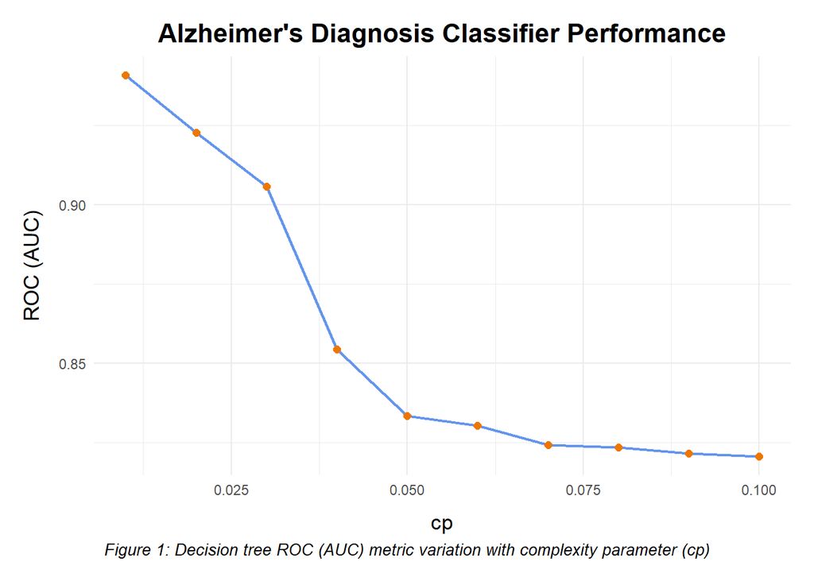

```r
ggplot(dectree.model$results, aes(x = cp, y = ROC)) +
  geom_line(color = "cornflowerblue", size = 0.8) +
  geom_point(color = "darkorange2", size = 2) +
  labs(
    title = "Alzheimer's Diagnosis Classifier Performance",
    y = "ROC (AUC)",
    caption = "Figure 1: Decision tree ROC (AUC) metric variation with complexity parameter (cp)"
  ) +
  theme_minimal() +
  theme(
    axis.title.x = element_text(size = 13, margin = ggplot2::margin(t = 10)),
    axis.title.y = element_text(size = 13, margin = ggplot2::margin(r = 10)),
    plot.margin = unit(c(0.5, 0.5, 0.5, 0.5), "cm"),
    plot.title = element_text(face = "bold", hjust = 0.5, size = 16),
    plot.caption.position = "plot",
    plot.caption = element_text(face = "italic", size = 10, hjust = 0.5)
  )
```

## Data Source

Alzheimer’s Disease Dataset https://www.kaggle.com/dsv/8668279 10.34740/KAGGLE/DSV/8668279 Kaggle Rabie El Kharoua, 2024